# DSA2101 Group Project on Valentine’s Day Consumption

# 1 Introduction

**Question of interest:**

What are the significant trends in gift preferences across different categories over time, age and gender?

The data set contains information on the different types of gifts people in the United States spent on for Valentine’s Day from 2010 to 2022. There are 3 tables provided.

The first, **`historical_spending`**, has all its variables as doubles. It shows the yearly average amount spent per person on the types of gifts, spanning from 2010 to 2022. The table also includes the percentage proportion of people celebrating Valentine’s Day across the years. The second table, **`gifts_age`**, has `Age` as a character class, and all other variables as doubles. It comprises the average proportion of those celebrating spending on each of the gift categories in percentage, differentiated by 6 age ranges. The ages range from 18 to above 65. The table also contains the percentage proportion of people celebrating Valentine’s Day across the ages. The third table, **`gifts_gender`**, has `Gender` as a character class, and all other variables as doubles. Similar to **`gifts_age`**, it displays the average proportion of those celebrating who are spending on each of the gift categories. It also has the percentage of each of the genders who were celebrating Valentine’s Day.

| Data Description for historical_spending.csv Variable | Data Description for historical_spending.csv Description |
| --- | --- |
| Year | Year |
| PercentCelebrating | Percent of people celebrating Valentines Day |
| PerPerson | Average amount each person is spending |
| Candy | Average amount spending on candy |
| Flowers | Average amount spending on flowers |
| Jewelry | Average amount spending on jewelry |
| GreetingCards | Average amount spending on greeting cards |
| EveningOut | Average amount spending on an evening out |
| Clothing | Average amount spending on clothing |
| GiftCards | Average amount spending on gift cards |

| Data Description for gifts_age.csv Variable | Data Description for gifts_age.csv Description |
| --- | --- |
| Age | Age |
| SpendingCelebrating | Percent spending money on or celebrating Valentines Day |
| Candy | Average percent spending on candy |
| Flowers | Average percent spending on flowers |
| Jewelry | Average percent spending on jewelry |
| GreetingCards | Average percent spending on greeting cards |
| EveningOut | Average percent spending on an evening out |
| Clothing | Average percent spending on clothing |
| GiftCards | Average percent spending on gift cards |

| Data Description for gifts_gender.csv Variable | Data Description for gifts_gender.csv Description |
| --- | --- |
| Gender | Gender only including Men or Women |
| SpendingCelebrating | Percent spending money on or celebrating Valentines Day |
| Candy | Average percent spending on candy |
| Flowers | Average percent spending on flowers |
| Jewelry | Average percent spending on jewelry |
| GreetingCards | Average percent spending on greeting cards |
| EveningOut | Average percent spending on an evening out |
| Clothing | Average percent spending on clothing |
| GiftCards | Average percent spending on gift cards |

# 2 Data cleaning and summary

```r
historical_spending <- readr::read_csv('https://raw.githubusercontent.com/rfordatascience/tidytuesday/master/data/2024/2024-02-13/historical_spending.csv')

gifts_age <- readr::read_csv('https://raw.githubusercontent.com/rfordatascience/tidytuesday/master/data/2024/2024-02-13/gifts_age.csv')

gifts_gender <- readr::read_csv('https://raw.githubusercontent.com/rfordatascience/tidytuesday/master/data/2024/2024-02-13/gifts_gender.csv')
```

```r
library(dplyr)
library(tidyverse)
library(patchwork)
library(ggplot2)
library(viridis)
library(reshape2)
```

## 2.1 Data cleaning for **`historical_spending`** dataset

```r
categorical_spending <- historical_spending %>%
  select(-PercentCelebrating, -PerPerson) %>%
  melt(id.vars = "Year") %>%
  rename(Categories = "variable")

perperson_percentceleb <- historical_spending %>%
  select(Year, PercentCelebrating, PerPerson) %>%
  melt(id.vars = "Year") %>%
  rename(Categories = "variable")
```

## 2.2 Data cleaning for **`gifts_age`** dataset

```r
gifts_age_cleaned <- gifts_age %>%
  rename(`Greeting Cards`= 6, `Gifts Cards`= 9, `Evening Out`= 7) %>%
  pivot_longer(3:9, names_to = "Category", values_to = "Percentage") %>%
  group_by(Age) %>%
  mutate(Category = fct_reorder(Category, -Percentage)) %>%
  ungroup()
```

## 2.3 Data cleaning for **`gifts_gender`** dataset

```r
gifts_gender_cleaned <- gifts_gender %>%
   rename(
    "Greeting Cards" = GreetingCards,
    "Evening Out" = EveningOut,
    "Gift Cards" = GiftCards
  ) %>%
  pivot_longer(3:9, names_to = "category", values_to = "percentage") %>%
  select(-2) %>%
  group_by(Gender) %>%
  mutate(category = reorder(category, percentage)) %>%
  ungroup()
```

# 3 Visualisations

For convenience, we save background setting as **theme_customised** which will be used for three visualisations.

```r
theme_customised <- theme(
    panel.background = element_rect(fill = "white", color = NA),
    plot.background = element_rect(fill = "white", color = NA),
    panel.grid.major = element_line(color = alpha("lightgray",0.5), linewidth = 0.5),
    panel.grid.minor = element_line(color = alpha("lightgray", 0.5), linewidth = 0.25)
)
```

## 3.1 Historical_spending

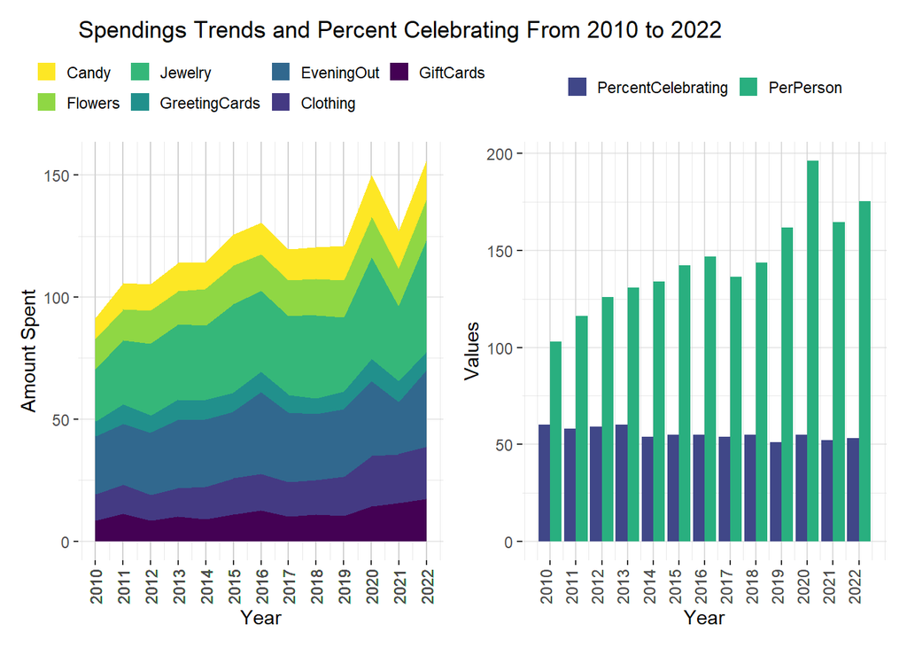

```r
plot1 <- ggplot(categorical_spending, aes(Year, value, fill=factor(Categories))) +
    geom_area() +
    ylab("Amount Spent") +
    labs(title = "Spendings Trends and Percent Celebrating From 2010 to 2022") +
    theme(legend.position = "top",
          legend.key.size = unit(0.4, "cm"),
          legend.title = element_blank(),
          axis.text.x = element_text(angle = 90, vjust = 0.5),
          plot.title = element_text(hjust = 0)) +
    scale_x_continuous("Year", labels = as.character(categorical_spending$Year),
                       breaks = categorical_spending$Year) +
  scale_fill_viridis(discrete=T,direction = -1) +
  theme_customised



plot2 <- ggplot(perperson_percentceleb, aes(Year, value, fill = factor(Categories))) +
  geom_bar(stat = "identity", position = "dodge") +
  ylab("Values") +
  theme(
    legend.position = "top",
    legend.key.size = unit(0.4, "cm"),
    legend.title = element_blank(),
    axis.text.x = element_text(angle = 90, vjust = 0.1)
  ) +
  scale_x_continuous(
    "Year",
    labels = as.character(perperson_percentceleb$Year),
    breaks = perperson_percentceleb$Year
  ) +
  scale_fill_manual(
    values = c("PercentCelebrating" = "#404788FF", "PerPerson" = "#29AF7FFF"),
    name = "",
    labels = c("PercentCelebrating", "PerPerson")
  ) +
    theme_customised


plot1 | plot2
```

## 3.2 Age

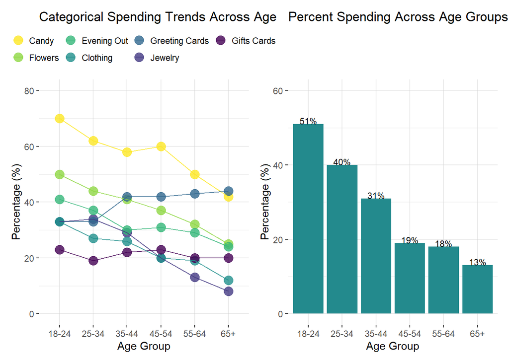

```r
plot3 <- gifts_age_cleaned  %>%
  ggplot(aes(x = Age, y = Percentage, colour = Category, group = Category)) +
  geom_point(alpha = 0.8, size=4) +
  geom_line(alpha = 0.8) +
  ylim(0,80) +
  labs(title = "Categorical Spending Trends Across Age",
       x = "Age Group", y = "Percentage (%)") +
  theme(legend.position = "top",
        legend.key.size = unit(0.4, "cm"),
        legend.title = element_blank()) +
  scale_colour_viridis(discrete=T , direction = -1) +
  theme_customised


plot4 <- gifts_age %>%
  select(1,2) %>%
  ggplot(aes(x=Age, y=SpendingCelebrating)) +
  geom_col(fill="#238A8DFF") +
  geom_text(aes(label=paste0(SpendingCelebrating, "%")),  size = 3,
            position=position_dodge(0.9), vjust="bottom") +
  ylim(0,60) +
  labs(title = "Percent Spending Across Age Groups",
       x = "Age Group", y = "Percentage (%)") +
  theme_customised

plot3 | plot4
```

## 3.3 Gender

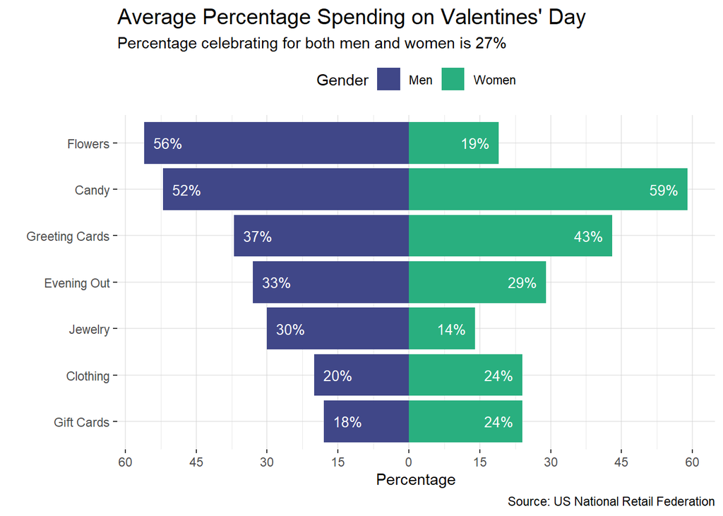

```r
plot5 <- ggplot(gifts_gender_cleaned, aes(x = category, y = percentage, fill = Gender)) +
  geom_col(data = gifts_gender_cleaned %>% filter(Gender == "Women")) +
  geom_col(data = gifts_gender_cleaned %>% filter(Gender == "Men"), aes(y = -percentage)) +
  geom_text(data = gifts_gender_cleaned %>% filter(Gender == "Women"),
            aes(y = percentage - 5, label = paste0(percentage, "%")),
            color = "white", size = 3.5) +
  geom_text(data = gifts_gender_cleaned %>% filter(Gender == "Men"),
            aes(y = -percentage + 5, label = paste0(percentage, "%")),
            color = "white", size = 3.5) +
  coord_flip() +
  labs(title = "Average Percentage Spending on Valentines' Day",
       subtitle = "Percentage celebrating for both men and women is 27%",
       x = "", y = "Percentage", caption = "Source: US National Retail Federation") +
  scale_y_continuous(
    breaks = seq(-60, 60, by = 15),
    labels = abs(seq(-60, 60, by = 15))) +
  scale_fill_manual(
    values = c("Men" = "#404788FF", "Women" = "#29AF7FFF"),
    name = "Gender",
    labels = c("Men", "Women")) +
  theme(plot.title = element_text(size = 15),
        legend.position = "top") +
  theme_customised

plot5
```

# 4 Discussion

## 4.2 Spendings by Age Group

Most Categories, except for `Greeting Cards` and `Gift Cards`, show a decrease in spending on Valentine’s Day as age increases. The decreases range from 40% for Candy to 75.7% for Jewelry. One reason for this trend can be that older people are less interested in consumerism and materialism related to Valentine’s Day. According to Zayas et al. (2017), older people had less positive views of roses and gift chocolates which symbolise love. This result suggests that they are less likely to buy these items for Valentine’s Day. This aligns with our visualisation that the percentage of people spending or celebrating on Valentine’s Day decreases with age. For `Greeting Cards`, about one third of young people (18-34) spend on them, while more than two fifths of older people (34+) do so. The percentage stays consistent for those aged 35 and above. This indicates that many people like to give greeting cards to others on Valentine’s Day, especially the older adults. In an age of digital communication, people still enjoy showing their feelings through physical greeting cards. Unlike emails or massages, a physical card that is thoughtfully chosen, written and decorated can express genuine affection. According to Charles (2020), Valentine’s Day remains the second most popular card-sending holiday in the U.S., after Christmas. The percentage of people purchasing `Gift Cards` remains stable across age groups, staying at around 21%. Gift cards are popular because they allow the recipient to choose what they want. Instead of struggling to find the perfect gift, giving gift cards shifts the decision to the recipient, ensuring satisfaction for both sides.

## 4.3 Spendings by Gender

Pyramid ordered bar chart is used for the third visualisation as we could see the spending difference across genders clearly. Among people celebrating Valentine’s Day, the primary insights reveal differences in spending patterns between men and women across gift categories. The chart highlights which items each gender tends to spend more on, reflecting distinct preferences and behaviours. For example, women may favour thoughtful gifts such as `Greeting Cards`, while men lean toward classic gifts such as `Flowers` and `Jewelry`. The largest difference is in `Flowers`, suggesting that flowers are a particularly popular gift choice among men. The reason why gifting lowers became so popular may stem from the Victorian era, when dictionaries were created just to help people decipher the flower meanings. People used it to express secret messages behind each flower—a popular way to convey love and appreciation for one another (Bloom & wild, n.d.). `Jewelry` is the second largest spending difference between genders. They seem to be a popular choice as gifts for women, as compared to women buying for men or themselves, backed up by research showing about 62% of those buying women’s jewelry were gifting them (Jck., 2016).

## 4.4 Overall Summary

Overall, we observe a trend where spending on Valentine’s Day has increased over time, while participation has decreased. This could be attributed to economic factors, such as the impacts of COVID-19 and broader economic uncertainty. From the visualisations, it is evident that although `Jewelry` and `Evening Out` command the highest spending, more people opt for gifts like `Candy`, `Flowers`, and `Greeting Cards`. These differences are most likely due to the much higher costs of jewelry and dinners compared to the others. By analysing these visualisations, we gain a comprehensive understanding of people’s spending habits and gift preferences across different categories, age groups, and genders. This detailed view helps us make links between economic conditions, personal preferences, and generational differences and their impacts Valentine’s Day celebrations.

# 5 Teamwork

Our group comprises of Genie Tay Ting, Huang Samuel, Liu Zhengshuo, Pan Xinyi and Wang Qingyang. Everyone contributed during discussions and group meetings. Genie was in charge of writing the introduction, teamwork portion, overall summary, and creating the reference list. Huang Samuel was in charge of making the first visualisation (Years) and its description. Zhengshuo was in charge of data cleaning and summary. Xinyi was in charge of making the second visualisation (Age) and its description. Qingyang was in charge of making the third visualisation (Gender) and its description. Genie and Zhengshuo also helped out with miscellaneous tasks like researching possible reasons for the trends identified.

# 6 Reference List

**Data Source:**

‘Tidytuesday/Data/2024/2024-02-13/Readme.Md at Master · Rfordatascience/Tidytuesday’. GitHub, https://github.com/rfordatascience/tidytuesday/blob/master/data/2024/2024-02-13/readme.md.

**Other References:**

Bloom & Wild Flower Delivery | Flowers & Gifts. (n.d.). Bloom & Wild. https://www.bloomandwild.com/the-blog/the-history-of-valentines-day

Charles, R. (2020, February 11). Stationery stores are in trouble, but our love for Valentine’s Day cards burns hotter than ever. Washington Post; The Washington Post. https://www.washingtonpost.com/entertainment/books/stationery-stores-are-in-trouble-but-our-love-for-valentines-day-cards-burns-hotter-than-ever/2020/02/11/d4927154-4c40-11ea-9b5c-eac5b16dafaa_story.html

Deb, S., Cacciola, S., & Stein, M. (2020, March 11). Sports leagues bar fans and cancel games amid coronavirus outbreak. The New York Times. https://www.nytimes.com/2020/03/11/sports/basketball/warriors-coronavirus-fans.html

Dickler, J. (2021, February 11). Covid takes a toll on couples ahead of Valentine’s day. CNBC. https://www.cnbc.com/2021/02/11/covid-takes-a-toll-on-couples-ahead-of-valentines-day-.html

International Monetary Fund. (2020). World economic outlook: April 2020, the Great Lockdown. International Monetary Fund.

Jck. (2016, February 19). The Who, What, Where, How Much, and Why of Jewelry Shopping. JCK. https://www.jckonline.com/magazine-article/the-who-what-where-how-much-and-why-of-jewelry-shopping/

Zayas, V., Pandey, G., & Tabak, J. (2017). Red Roses and Gift Chocolates Are Judged More Positively in the U.S. Near Valentine’s Day: Evidence of Naturally Occurring Cultural Priming. Frontiers in Psychology, 8. https://doi.org/10.3389/fpsyg.2017.00355